# ExtraaLearn Project

## Context

The EdTech industry has been surging in the past decade immensely, and according to a forecast, the Online Education market would be worth $286.62bn by 2023 with a compound annual growth rate (CAGR) of 10.26% from 2018 to 2023. The modern era of online education has enforced a lot in its growth and expansion beyond any limit. Due to having many dominant features like ease of information sharing, personalized learning experience, transparency of assessment, etc, it is now preferable to traditional education.

In the present scenario due to the Covid-19, the online education sector has witnessed rapid growth and is attracting a lot of new customers. Due to this rapid growth, many new companies have emerged in this industry. With the availability and ease of use of digital marketing resources, companies can reach out to a wider audience with their offerings. The customers who show interest in these offerings are termed as leads. There are various sources of obtaining leads for Edtech companies, like

- The customer interacts with the marketing front on social media or other online platforms.
- The customer browses the website/app and downloads the brochure
- The customer connects through emails for more information.

The company then nurtures these leads and tries to convert them to paid customers. For this, the representative from the organization connects with the lead on call or through email to share further details.

## Objective

ExtraaLearn is an initial stage startup that offers programs on cutting-edge technologies to students and professionals to help them upskill/reskill. With a large number of leads being generated on a regular basis, one of the issues faced by ExtraaLearn is to identify which of the leads are more likely to convert so that they can allocate resources accordingly. You, as a data scientist at ExtraaLearn, have been provided the leads data to:

- Analyze and build an ML model to help identify which leads are more likely to convert to paid customers,
- Find the factors driving the lead conversion process
- Create a profile of the leads which are likely to convert

## Data Description

The data contains the different attributes of leads and their interaction details with ExtraaLearn. The detailed data dictionary is given below.

**Data Dictionary**

- ID: ID of the lead
- age: Age of the lead
- current_occupation: Current occupation of the lead. Values include 'Professional','Unemployed',and 'Student'
- first_interaction: How did the lead first interacted with ExtraaLearn. Values include 'Website', 'Mobile App'
- profile_completed: What percentage of profile has been filled by the lead on the website/mobile app. Values include Low - (0-50%), Medium - (50-75%), High (75-100%)
- website_visits: How many times has a lead visited the website
- time_spent_on_website: Total time spent on the website
- page_views_per_visit: Average number of pages on the website viewed during the visits.
- last_activity: Last interaction between the lead and ExtraaLearn.
  - Email Activity: Seeking for details about program through email, Representative shared information with lead like brochure of program , etc
  - Phone Activity: Had a Phone Conversation with representative, Had conversation over SMS with representative, etc
  - Website Activity: Interacted on live chat with representative, Updated profile on website, etc
- print_media_type1: Flag indicating whether the lead had seen the ad of ExtraaLearn in the Newspaper.
- print_media_type2: Flag indicating whether the lead had seen the ad of ExtraaLearn in the Magazine.
- digital_media: Flag indicating whether the lead had seen the ad of ExtraaLearn on the digital platforms.
- educational_channels: Flag indicating whether the lead had heard about ExtraaLearn in the education channels like online forums, discussion threads, educational websites, etc.
- referral: Flag indicating whether the lead had heard about ExtraaLearn through reference.
- status: Flag indicating whether the lead was converted to a paid customer or not.

## Importing necessary libraries and data

```python
# Importing the basic libraries we will require for the project

# Libraries to help with reading and manipulating data
import pandas as pd
import numpy as np

# Libaries to help with data visualization
import matplotlib.pyplot as plt
import seaborn as sns
sns.set()

# Importing the Machine Learning models we require from Scikit-Learn
from sklearn.tree import DecisionTreeClassifier
from sklearn import tree
from sklearn.ensemble import RandomForestClassifier

# Importing the other functions we may require from Scikit-Learn
from sklearn.model_selection import train_test_split, GridSearchCV
from sklearn.preprocessing import MinMaxScaler, LabelEncoder, OneHotEncoder

# To get diferent metric scores
from sklearn.metrics import confusion_matrix,classification_report,roc_auc_score,precision_recall_curve,roc_curve,make_scorer

# Code to ignore warnings from function usage
import warnings;
import numpy as np
warnings.filterwarnings('ignore')

# To get diferent metric scores
import sklearn.metrics as metrics
from sklearn.metrics import (
    f1_score,
    accuracy_score,
    recall_score,
    precision_score,
    confusion_matrix,
    classification_report,
    roc_auc_score,
    precision_recall_curve,
    roc_curve,
    make_scorer,
)
```

```python
# Loading the dataset
data=pd.read_csv("ExtraaLearn.csv")
```

## Data Overview

- Observations
- Sanity checks

```python
data.head()
```

|  | ID | age | current_occupation | first_interaction | profile_completed | website_visits | time_spent_on_website | page_views_per_visit | last_activity | print_media_type1 | print_media_type2 | digital_media | educational_channels | referral | status |
| --- | --- | --- | --- | --- | --- | --- | --- | --- | --- | --- | --- | --- | --- | --- | --- |
| 0 | EXT001 | 57 | Unemployed | Website | High | 7 | 1639 | 1.861 | Website Activity | Yes | No | Yes | No | No | 1 |
| 1 | EXT002 | 56 | Professional | Mobile App | Medium | 2 | 83 | 0.320 | Website Activity | No | No | No | Yes | No | 0 |
| 2 | EXT003 | 52 | Professional | Website | Medium | 3 | 330 | 0.074 | Website Activity | No | No | Yes | No | No | 0 |
| 3 | EXT004 | 53 | Unemployed | Website | High | 4 | 464 | 2.057 | Website Activity | No | No | No | No | No | 1 |
| 4 | EXT005 | 23 | Student | Website | High | 4 | 600 | 16.914 | Email Activity | No | No | No | No | No | 0 |

```python
data.tail()
```

|  | ID | age | current_occupation | first_interaction | profile_completed | website_visits | time_spent_on_website | page_views_per_visit | last_activity | print_media_type1 | print_media_type2 | digital_media | educational_channels | referral | status |
| --- | --- | --- | --- | --- | --- | --- | --- | --- | --- | --- | --- | --- | --- | --- | --- |
| 4607 | EXT4608 | 35 | Unemployed | Mobile App | Medium | 15 | 360 | 2.170 | Phone Activity | No | No | No | Yes | No | 0 |
| 4608 | EXT4609 | 55 | Professional | Mobile App | Medium | 8 | 2327 | 5.393 | Email Activity | No | No | No | No | No | 0 |
| 4609 | EXT4610 | 58 | Professional | Website | High | 2 | 212 | 2.692 | Email Activity | No | No | No | No | No | 1 |
| 4610 | EXT4611 | 57 | Professional | Mobile App | Medium | 1 | 154 | 3.879 | Website Activity | Yes | No | No | No | No | 0 |
| 4611 | EXT4612 | 55 | Professional | Website | Medium | 4 | 2290 | 2.075 | Phone Activity | No | No | No | No | No | 0 |

```python
data.shape
```

```
(4612, 15)
```

The dataset has 4612 rows and 15 columns.

```python
data.info()
```

```
<class 'pandas.core.frame.DataFrame'>
RangeIndex: 4612 entries, 0 to 4611
Data columns (total 15 columns):
 #   Column                 Non-Null Count  Dtype
---  ------                 --------------  -----
 0   ID                     4612 non-null   object
 1   age                    4612 non-null   int64
 2   current_occupation     4612 non-null   object
 3   first_interaction      4612 non-null   object
 4   profile_completed      4612 non-null   object
 5   website_visits         4612 non-null   int64
 6   time_spent_on_website  4612 non-null   int64
 7   page_views_per_visit   4612 non-null   float64
 8   last_activity          4612 non-null   object
 9   print_media_type1      4612 non-null   object
 10  print_media_type2      4612 non-null   object
 11  digital_media          4612 non-null   object
 12  educational_channels   4612 non-null   object
 13  referral               4612 non-null   object
 14  status                 4612 non-null   int64
dtypes: float64(1), int64(4), object(10)
memory usage: 540.6+ KB
```

All the columns have 4612 entries which means that there are no missing values.

```python
#Confirming the percentage of missing values
pd.DataFrame(data={'% of Missing Values':round(data.isna().sum()/data.isna().count()*100,2)}).sort_values(by='% of Missing Values',ascending=False)
```

|  | % of Missing Values |
| --- | --- |
| ID | 0.0 |
| age | 0.0 |
| current_occupation | 0.0 |
| first_interaction | 0.0 |
| profile_completed | 0.0 |
| website_visits | 0.0 |
| time_spent_on_website | 0.0 |
| page_views_per_visit | 0.0 |
| last_activity | 0.0 |
| print_media_type1 | 0.0 |
| print_media_type2 | 0.0 |
| digital_media | 0.0 |
| educational_channels | 0.0 |
| referral | 0.0 |
| status | 0.0 |

We are now confirmed that there are no missing values.

## **Check the number of unique values in each column**

```python
data.nunique()
```

```
ID                       4612
age                        46
current_occupation          3
first_interaction           2
profile_completed           3
website_visits             27
time_spent_on_website    1623
page_views_per_visit     2414
last_activity               3
print_media_type1           2
print_media_type2           2
digital_media               2
educational_channels        2
referral                    2
status                      2
dtype: int64
```

# We can drop the ID column as that column won't help in the modelling.

```python
# Dropping the 'ID' column
data.drop(columns='ID',inplace=True)
```

# Statistical summary of the data

```python
data.describe().T
```

|  | count | mean | std | min | 25% | 50% | 75% | max |
| --- | --- | --- | --- | --- | --- | --- | --- | --- |
| age | 4612.0 | 46.201214 | 13.161454 | 18.0 | 36.00000 | 51.000 | 57.00000 | 63.000 |
| website_visits | 4612.0 | 3.566782 | 2.829134 | 0.0 | 2.00000 | 3.000 | 5.00000 | 30.000 |
| time_spent_on_website | 4612.0 | 724.011275 | 743.828683 | 0.0 | 148.75000 | 376.000 | 1336.75000 | 2537.000 |
| page_views_per_visit | 4612.0 | 3.026126 | 1.968125 | 0.0 | 2.07775 | 2.792 | 3.75625 | 18.434 |
| status | 4612.0 | 0.298569 | 0.457680 | 0.0 | 0.00000 | 0.000 | 1.00000 | 1.000 |

- The mean age is 46 and the median age is 51.
- The page views per visit might have some outliers as the 75th percentile value is 3.75625 while the max vaue is 18.434
- The time spent on website might have some outliers as the 75th percentile value is 1336.75 while the max value is 2537.00.
- The website visits might have some outliers as the 75th percentile value is 5.0 while the max vaue is 30.0.

# Check the count of each unique category in each of the categorical variables.

```python
# Making a list of all catrgorical variables
cat_col=['current_occupation', 'first_interaction', 'profile_completed', 'last_activity',
         'print_media_type1', 'print_media_type2', 'digital_media', 'educational_channels',
         'referral']

# Printing number of count of each unique value in each column
for column in cat_col:
    print(data[column].value_counts())
    print('-'*50)
```

```
Professional    2616
Unemployed      1441
Student          555
Name: current_occupation, dtype: int64
--------------------------------------------------
Website       2542
Mobile App    2070
Name: first_interaction, dtype: int64
--------------------------------------------------
High      2264
Medium    2241
Low        107
Name: profile_completed, dtype: int64
--------------------------------------------------
Email Activity      2278
Phone Activity      1234
Website Activity    1100
Name: last_activity, dtype: int64
--------------------------------------------------
No     4115
Yes     497
Name: print_media_type1, dtype: int64
--------------------------------------------------
No     4379
Yes     233
Name: print_media_type2, dtype: int64
--------------------------------------------------
No     4085
Yes     527
Name: digital_media, dtype: int64
--------------------------------------------------
No     3907
Yes     705
Name: educational_channels, dtype: int64
--------------------------------------------------
No     4519
Yes      93
Name: referral, dtype: int64
--------------------------------------------------
```

- Majority of the people are professionals with students comprising the least number.
- Out of 4612 people, only 93 have come through referrals.

```python
# Converting the data type of each categorical variable to 'category'
for column in cat_col:
    data[column]=data[column].astype('category')
```

```python
data.info()
```

```
<class 'pandas.core.frame.DataFrame'>
RangeIndex: 4612 entries, 0 to 4611
Data columns (total 14 columns):
 #   Column                 Non-Null Count  Dtype
---  ------                 --------------  -----
 0   age                    4612 non-null   int64
 1   current_occupation     4612 non-null   category
 2   first_interaction      4612 non-null   category
 3   profile_completed      4612 non-null   category
 4   website_visits         4612 non-null   int64
 5   time_spent_on_website  4612 non-null   int64
 6   page_views_per_visit   4612 non-null   float64
 7   last_activity          4612 non-null   category
 8   print_media_type1      4612 non-null   category
 9   print_media_type2      4612 non-null   category
 10  digital_media          4612 non-null   category
 11  educational_channels   4612 non-null   category
 12  referral               4612 non-null   category
 13  status                 4612 non-null   int64
dtypes: category(9), float64(1), int64(4)
memory usage: 221.9 KB
```

```python
df = data.copy()
```

## Exploratory Data Analysis (EDA)

- EDA is an important part of any project involving data.
- It is important to investigate and understand the data better before building a model with it.
- A few questions have been mentioned below which will help you approach the analysis in the right manner and generate insights from the data.
- A thorough analysis of the data, in addition to the questions mentioned below, should be done.

```python
# Defining the hist_box() function
def hist_box(data, col):
    f, (ax_box, ax_hist) = plt.subplots(2, sharex=True, gridspec_kw={'height_ratios': (0.15, 0.85)}, figsize=(12, 6))
    # Adding a graph in each part
    sns.boxplot(data=data, x=col, ax=ax_box, showmeans=True)
    sns.histplot(data=data, x=col, kde=True, ax=ax_hist)
    plt.show()
```

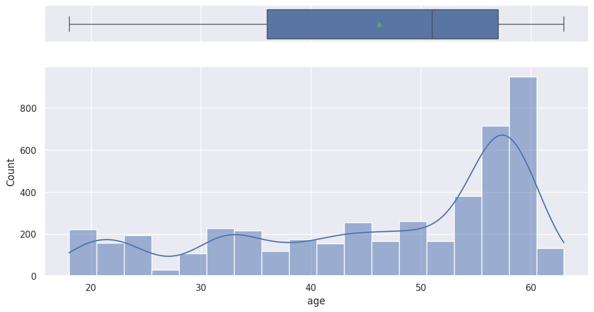

```python
hist_box(df, "age")
```

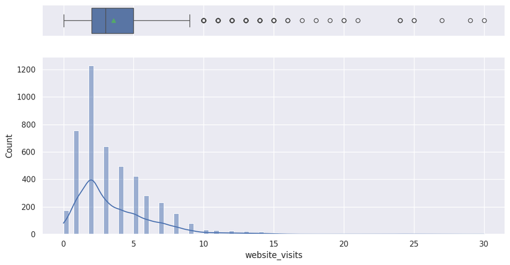

```python
hist_box(df, 'website_visits')
```

```python
df[df['website_visits']>10]
```

|  | age | current_occupation | first_interaction | profile_completed | website_visits | time_spent_on_website | page_views_per_visit | last_activity | print_media_type1 | print_media_type2 | digital_media | educational_channels | referral | status |
| --- | --- | --- | --- | --- | --- | --- | --- | --- | --- | --- | --- | --- | --- | --- |
| 6 | 56 | Professional | Mobile App | Medium | 13 | 625 | 2.015 | Website Activity | No | No | Yes | No | No | 1 |
| 31 | 55 | Unemployed | Website | Medium | 13 | 1055 | 1.373 | Email Activity | No | No | Yes | Yes | No | 1 |
| 32 | 58 | Professional | Mobile App | High | 12 | 1151 | 18.434 | Phone Activity | No | No | No | Yes | No | 0 |
| 66 | 59 | Unemployed | Mobile App | Medium | 25 | 311 | 2.184 | Phone Activity | No | No | Yes | No | No | 0 |
| 201 | 57 | Professional | Mobile App | High | 14 | 66 | 2.043 | Email Activity | No | No | No | Yes | No | 0 |
| ... | ... | ... | ... | ... | ... | ... | ... | ... | ... | ... | ... | ... | ... | ... |
| 4566 | 59 | Unemployed | Mobile App | High | 13 | 30 | 3.200 | Website Activity | No | No | No | Yes | No | 0 |
| 4571 | 54 | Professional | Website | High | 12 | 1513 | 5.703 | Email Activity | No | No | No | No | No | 1 |
| 4583 | 49 | Professional | Website | Medium | 24 | 1039 | 2.064 | Email Activity | Yes | No | No | No | No | 1 |
| 4589 | 21 | Student | Website | High | 16 | 251 | 2.108 | Phone Activity | No | No | No | No | No | 0 |
| 4607 | 35 | Unemployed | Mobile App | Medium | 15 | 360 | 2.170 | Phone Activity | No | No | No | Yes | No | 0 |

120 rows × 14 columns

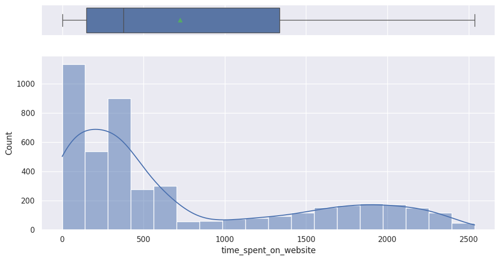

```python
hist_box(df, 'time_spent_on_website')
```

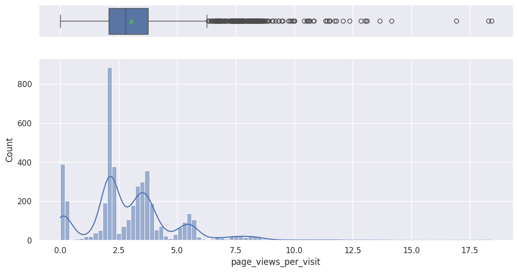

```python
hist_box(df, 'page_views_per_visit')
```

```python
df[df['page_views_per_visit']>6.75]
```

|  | age | current_occupation | first_interaction | profile_completed | website_visits | time_spent_on_website | page_views_per_visit | last_activity | print_media_type1 | print_media_type2 | digital_media | educational_channels | referral | status |
| --- | --- | --- | --- | --- | --- | --- | --- | --- | --- | --- | --- | --- | --- | --- |
| 4 | 23 | Student | Website | High | 4 | 600 | 16.914 | Email Activity | No | No | No | No | No | 0 |
| 32 | 58 | Professional | Mobile App | High | 12 | 1151 | 18.434 | Phone Activity | No | No | No | Yes | No | 0 |
| 47 | 35 | Professional | Mobile App | Medium | 2 | 497 | 7.050 | Email Activity | No | No | No | No | No | 0 |
| 110 | 31 | Professional | Website | High | 1 | 187 | 7.364 | Email Activity | No | No | No | Yes | No | 1 |
| 121 | 56 | Professional | Mobile App | Medium | 2 | 561 | 6.887 | Email Activity | No | No | No | No | No | 0 |
| ... | ... | ... | ... | ... | ... | ... | ... | ... | ... | ... | ... | ... | ... | ... |
| 4470 | 40 | Unemployed | Mobile App | High | 2 | 1747 | 6.810 | Email Activity | No | No | No | No | Yes | 0 |
| 4507 | 33 | Professional | Mobile App | High | 5 | 83 | 6.822 | Email Activity | No | No | No | No | No | 0 |
| 4514 | 42 | Professional | Mobile App | Medium | 2 | 762 | 7.997 | Phone Activity | No | No | No | No | No | 0 |
| 4572 | 55 | Unemployed | Mobile App | High | 1 | 617 | 7.397 | Phone Activity | No | No | No | No | No | 0 |
| 4597 | 20 | Student | Website | Medium | 2 | 364 | 8.246 | Email Activity | No | No | No | Yes | No | 0 |

232 rows × 14 columns

# Removing the outliers

The website_views and page_views_per_visit have outlier which we need to remove

```python
# Dropping observaions with website visits greater than 120. There are 120 such observations
df.drop(index=df[df.website_visits>10].index,inplace=True)

# Dropping observation with page views per visit greater than 6.75. There are 232 such observations
df.drop(index=df[df.page_views_per_visit>6.75].index,inplace=True)
```

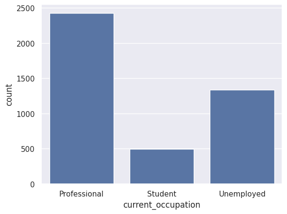

```python
sns.countplot(x = df['current_occupation'])
plt.show()
```

```python
df['current_occupation'].value_counts(normalize=True)
```

```
Professional    0.569050
Unemployed      0.314185
Student         0.116764
Name: current_occupation, dtype: float64
```

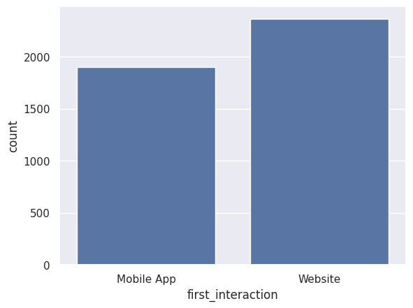

```python
sns.countplot(x = df['first_interaction'])
plt.show()
```

```python
df['first_interaction'].value_counts(normalize=True)
```

```
Website       0.554513
Mobile App    0.445487
Name: first_interaction, dtype: float64
```

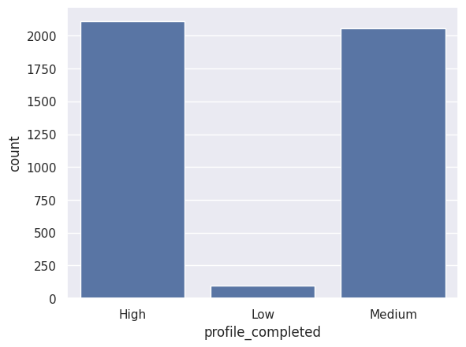

```python
sns.countplot(x = df['profile_completed'])
plt.show()
```

```python
df['profile_completed'].value_counts(normalize=True)
```

```
High      0.494959
Medium    0.482298
Low       0.022743
Name: profile_completed, dtype: float64
```

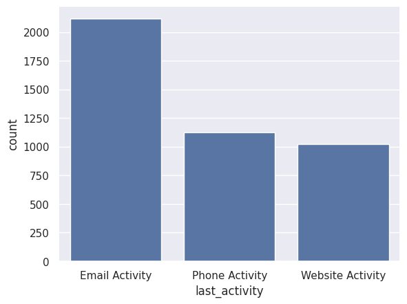

```python
sns.countplot(x = df['last_activity'])
plt.show()
```

```python
df['last_activity'].value_counts(normalize=True)
```

```
Email Activity      0.496600
Phone Activity      0.264009
Website Activity    0.239390
Name: last_activity, dtype: float64
```

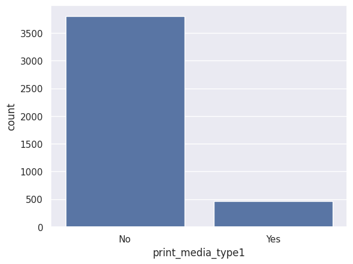

```python
sns.countplot(x = df['print_media_type1'])
plt.show()
```

```python
df['print_media_type1'].value_counts(normalize=True)
```

```
No     0.892145
Yes    0.107855
Name: print_media_type1, dtype: float64
```

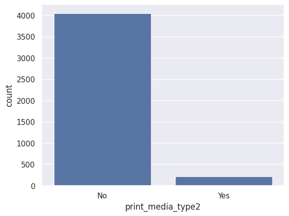

```python
sns.countplot(x = df['print_media_type2'])
plt.show()
```

```python
df['print_media_type2'].value_counts(normalize=True)
```

```
No     0.948886
Yes    0.051114
Name: print_media_type2, dtype: float64
```

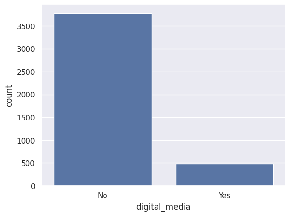

```python
sns.countplot(x = df['digital_media'])
plt.show()
```

```python
df['digital_media'].value_counts(normalize=True)
```

```
No     0.886753
Yes    0.113247
Name: digital_media, dtype: float64
```

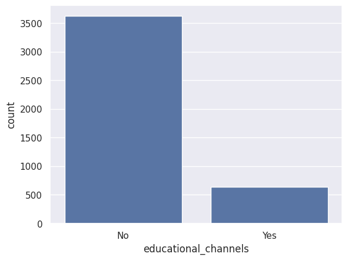

```python
sns.countplot(x = df['educational_channels'])
plt.show()
```

```python
df['educational_channels'].value_counts(normalize=True)
```

```
No     0.849707
Yes    0.150293
Name: educational_channels, dtype: float64
```

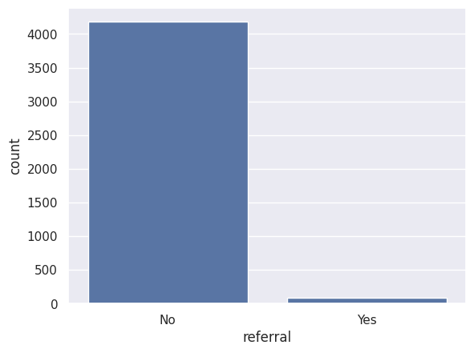

```python
sns.countplot(x = df['referral'])
plt.show()
```

```python
df['referral'].value_counts(normalize=True)
```

```
No     0.98007
Yes    0.01993
Name: referral, dtype: float64
```

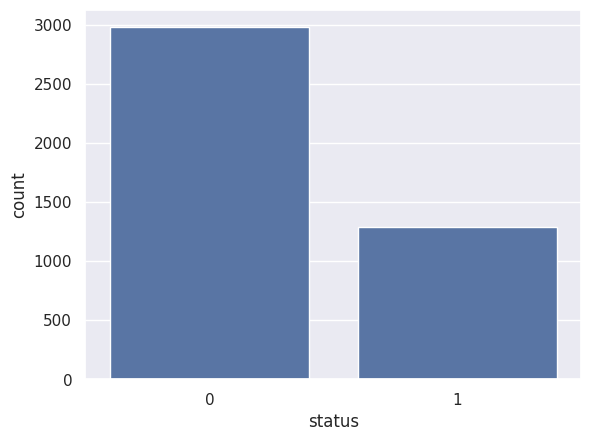

```python
sns.countplot(x = df['status'])
plt.show()
```

```python
df['status'].value_counts(normalize=True)
```

```
0    0.698242
1    0.301758
Name: status, dtype: float64
```

# Bivariate analysis

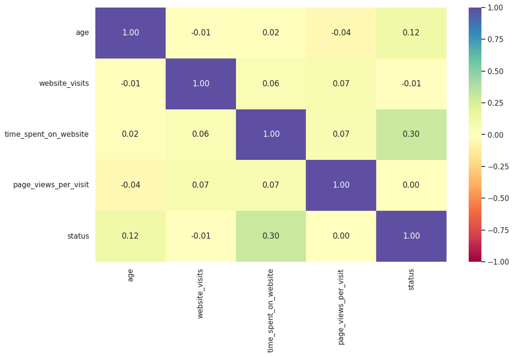

```python
cols_list = df.select_dtypes(include=np.number).columns.tolist()

plt.figure(figsize=(12, 7))
sns.heatmap(data[cols_list].corr(), annot=True, vmin=-1, vmax=1, fmt=".2f", cmap="Spectral")
plt.show()
```

- There is a weak correlation between time spent on the website and the status of the lead converting to be being a paid customer.
- There is not much correlaton between the other features.

```python
# Defining the stacked_barplot() function
def stacked_barplot(data,predictor,target,figsize=(10,6)):
  (pd.crosstab(data[predictor],data[target],normalize='index')*100).plot(kind='bar',figsize=figsize,stacked=True)
  plt.legend(loc="lower right")
  plt.ylabel(target)
```

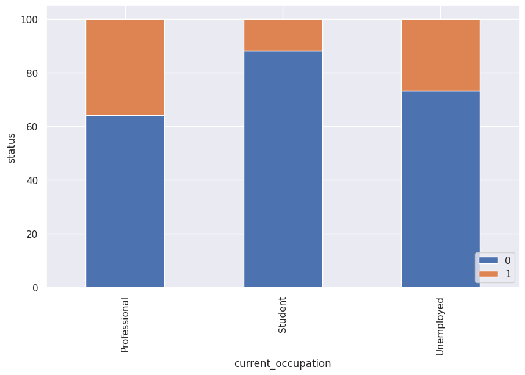

```python
stacked_barplot(df, "current_occupation", "status" )
```

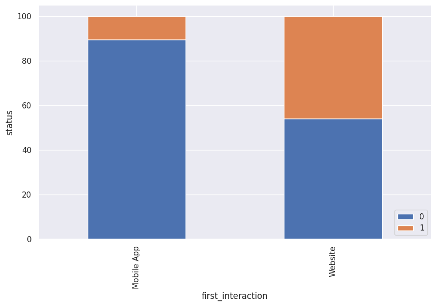

```python
stacked_barplot(df, "first_interaction", "status" )
```

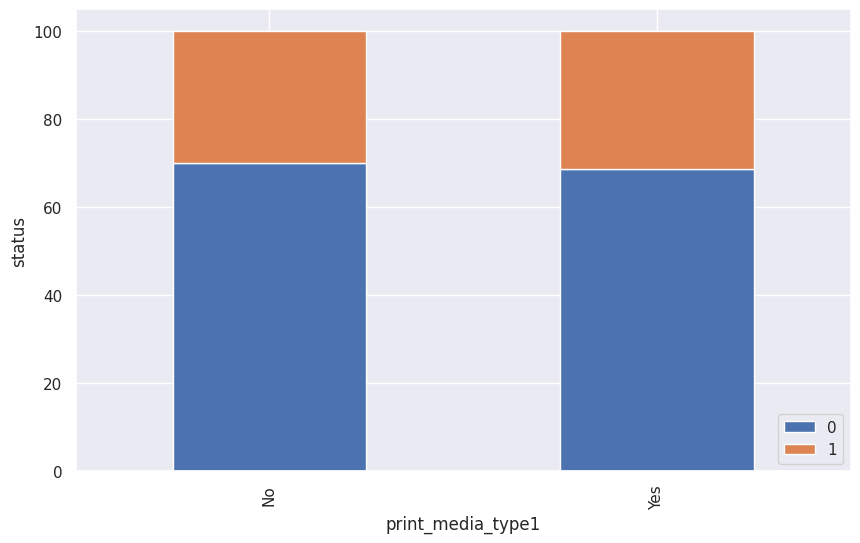

```python
stacked_barplot(df, "print_media_type1", "status" )
```

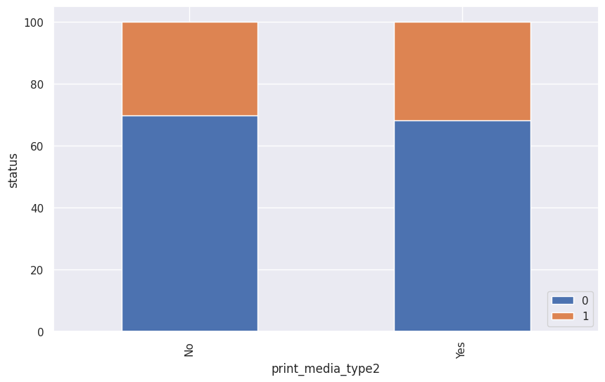

```python
stacked_barplot(df, "print_media_type2", "status" )
```

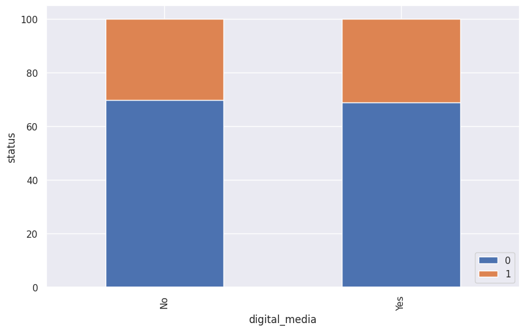

```python
stacked_barplot(df, "digital_media", "status" )
```

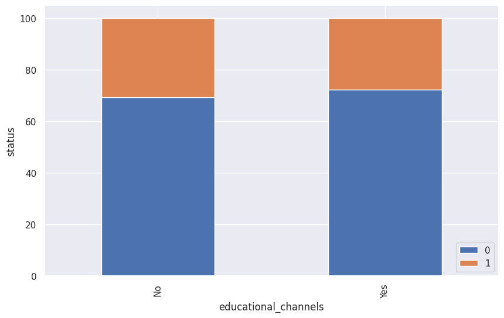

```python
stacked_barplot(df, "educational_channels", "status" )
```

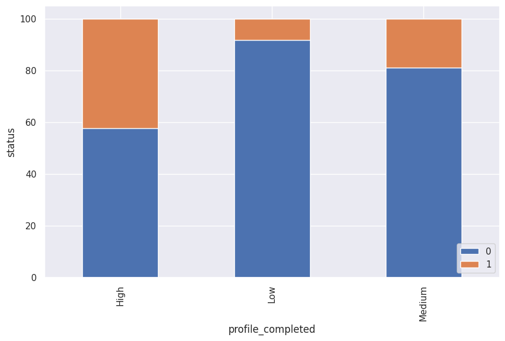

```python
stacked_barplot(df, "profile_completed", "status" )
```

**Mostly professionals and unemployed people participate in the program compared to students.**

**The first channels of interaction are through the website or mobile app. We can see from the data analysis that the first interaction through the mobile app does not have much impact. However, the first interaction through the website has significantly more impact than the mobile app.**

**It can be inferred that people who complete their profiles fully or partially have higher tendencies to become a paid customer.**

## Data Preprocessing

- Missing value treatment (if needed)
- Feature engineering (if needed)
- Outlier detection and treatment (if needed)
- Preparing data for modeling
- Any other preprocessing steps (if needed)

**There are no missing values**

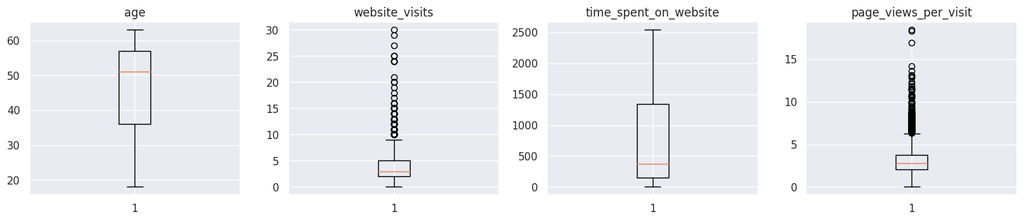

```python
# outlier detection using boxplot
numeric_columns = data.select_dtypes(include=np.number).columns.tolist()
# dropping release_year as it is a temporal variable
numeric_columns.remove("status")

plt.figure(figsize=(15, 12))

for i, variable in enumerate(numeric_columns):
    plt.subplot(4, 4, i + 1)
    plt.boxplot(data[variable], whis=1.5)
    plt.tight_layout()
    plt.title(variable)

plt.show()
```

```python
X = data.drop(["status"], axis=1)
Y = data['status']

#converting data types of columns to float
for column in ['website_visits', 'time_spent_on_website']:
    X[column]=X[column].astype('float')

#List of columns to create a dummy variables
col_dummy=['current_occupation', 'first_interaction', 'profile_completed',
           'last_activity', 'print_media_type1', 'print_media_type2',
           'digital_media', 'educational_channels', 'referral']
#Encoding categorical varaibles
X = pd.get_dummies(X, columns=col_dummy, drop_first=True)

# Splitting the data in 70:30 ratio for train to test data
X_train, X_test, y_train, y_test = train_test_split(
    X, Y, test_size=0.30, random_state=1
)
```

```python
print("Shape of Training set : ", X_train.shape)
print("Shape of test set : ", X_test.shape)
print("Percentage of classes in training set:")
print(y_train.value_counts(normalize=True))
print("Percentage of classes in test set:")
print(y_test.value_counts(normalize=True))
```

```
Shape of Training set :  (3228, 16)
Shape of test set :  (1384, 16)
Percentage of classes in training set:
0    0.704151
1    0.295849
Name: status, dtype: float64
Percentage of classes in test set:
0    0.695087
1    0.304913
Name: status, dtype: float64
```

## EDA

- It is a good idea to explore the data once again after manipulating it.

```python
X.head()
```

|  | age | website_visits | time_spent_on_website | page_views_per_visit | current_occupation_Student | current_occupation_Unemployed | first_interaction_Website | profile_completed_Low | profile_completed_Medium | last_activity_Phone Activity | last_activity_Website Activity | print_media_type1_Yes | print_media_type2_Yes | digital_media_Yes | educational_channels_Yes | referral_Yes |
| --- | --- | --- | --- | --- | --- | --- | --- | --- | --- | --- | --- | --- | --- | --- | --- | --- |
| 0 | 57 | 7.0 | 1639.0 | 1.861 | 0 | 1 | 1 | 0 | 0 | 0 | 1 | 1 | 0 | 1 | 0 | 0 |
| 1 | 56 | 2.0 | 83.0 | 0.320 | 0 | 0 | 0 | 0 | 1 | 0 | 1 | 0 | 0 | 0 | 1 | 0 |
| 2 | 52 | 3.0 | 330.0 | 0.074 | 0 | 0 | 1 | 0 | 1 | 0 | 1 | 0 | 0 | 1 | 0 | 0 |
| 3 | 53 | 4.0 | 464.0 | 2.057 | 0 | 1 | 1 | 0 | 0 | 0 | 1 | 0 | 0 | 0 | 0 | 0 |
| 4 | 23 | 4.0 | 600.0 | 16.914 | 1 | 0 | 1 | 0 | 0 | 0 | 0 | 0 | 0 | 0 | 0 | 0 |

```python
Y.head()
```

```
0    1
1    0
2    0
3    1
4    0
Name: status, dtype: int64
```

```python
# Function to print the classification report and get confusion matrix in a proper format

def metrics_score(actual, predicted):
    print(classification_report(actual, predicted))

    cm = confusion_matrix(actual, predicted)

    plt.figure(figsize = (8, 5))

    sns.heatmap(cm, annot = True,  fmt = '.2f', xticklabels = ['Not Converted', 'Converted'], yticklabels = ['Not Converted', 'Converted'])

    plt.ylabel('Actual')

    plt.xlabel('Predicted')

    plt.show()
```

## Building a Decision Tree model

```python
# Fitting the decision tree classifier on the training data
d_tree =  DecisionTreeClassifier(random_state=1)
d_tree.fit(X_train, y_train)
```

```
DecisionTreeClassifier(random_state=1)
```

```
              precision    recall  f1-score   support

           0       1.00      1.00      1.00      2273
           1       1.00      1.00      1.00       955

    accuracy                           1.00      3228
   macro avg       1.00      1.00      1.00      3228
weighted avg       1.00      1.00      1.00      3228
```

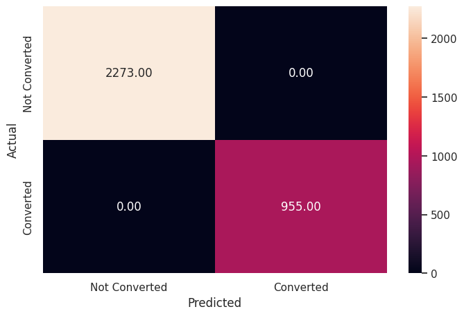

```python
# Checking performance on the training dataset
pred_train_dt = d_tree.predict(X_train)
metrics_score(y_train, pred_train_dt)
```

The model fits the training the data perfectly. Lets see how it performs for the test data.

```
              precision    recall  f1-score   support

           0       0.87      0.86      0.86       962
           1       0.69      0.70      0.70       422

    accuracy                           0.81      1384
   macro avg       0.78      0.78      0.78      1384
weighted avg       0.81      0.81      0.81      1384
```

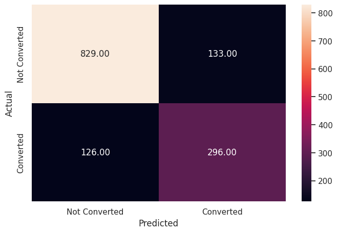

```python
# Checking performance on the testing data
y_pred_test1 = d_tree.predict(X_test)
metrics_score(y_test, y_pred_test1)
```

The model does not perform as well for the test data. This means that there is overfitting present on the training data and we need to tune the hyperparameters.

## Do we need to prune the tree?

```python
# Choose the type of classifier
d_tree_tuned = DecisionTreeClassifier(random_state = 7, class_weight = {0: 0.3, 1: 0.7})

# Grid of parameters to choose from
parameters = {'max_depth': np.arange(2, 10),
              'criterion': ['gini', 'entropy'],
              'min_samples_leaf': [5, 10, 20, 25]
             }

# Type of scoring used to compare parameter combinations - recall score for class 1
scorer = metrics.make_scorer(recall_score, pos_label = 1)

# Run the grid search
grid_obj = GridSearchCV(d_tree_tuned, parameters, scoring = scorer, cv = 5)

grid_obj = grid_obj.fit(X_train, y_train)

# Set the classifier to the best combination of parameters
d_tree_tuned = grid_obj.best_estimator_

# Fit the best algorithm to the data
d_tree_tuned.fit(X_train, y_train)
```

```
DecisionTreeClassifier(class_weight={0: 0.3, 1: 0.7}, criterion='entropy',
                       max_depth=3, min_samples_leaf=5, random_state=7)
```

```
              precision    recall  f1-score   support

           0       0.94      0.77      0.85      2273
           1       0.62      0.88      0.73       955

    accuracy                           0.80      3228
   macro avg       0.78      0.83      0.79      3228
weighted avg       0.84      0.80      0.81      3228
```

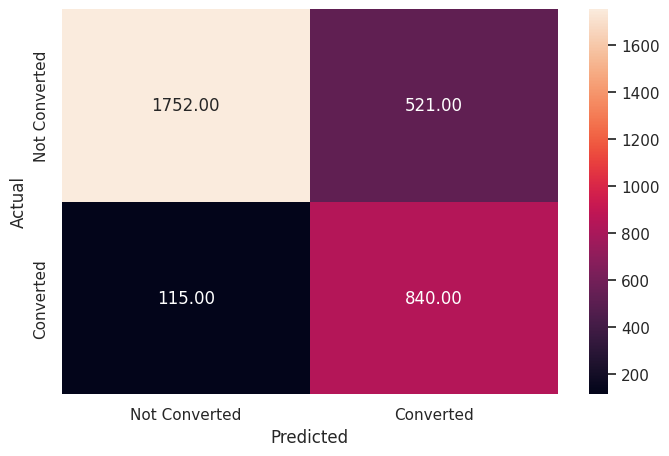

```python
# Checking performance on the training data
y_pred_train2 = d_tree_tuned.predict(X_train)
metrics_score(y_train,y_pred_train2)
```

```
              precision    recall  f1-score   support

           0       0.93      0.77      0.84       962
           1       0.62      0.86      0.72       422

    accuracy                           0.80      1384
   macro avg       0.77      0.82      0.78      1384
weighted avg       0.83      0.80      0.80      1384
```

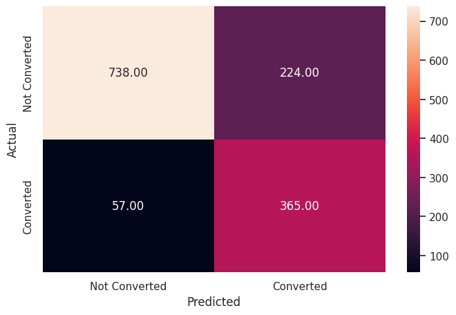

```python
# Checking performance on the training data
y_pred_test2 = d_tree_tuned.predict(X_test)
metrics_score(y_test,y_pred_test2)
```

Now the model gives similar results for both the training and testing data.

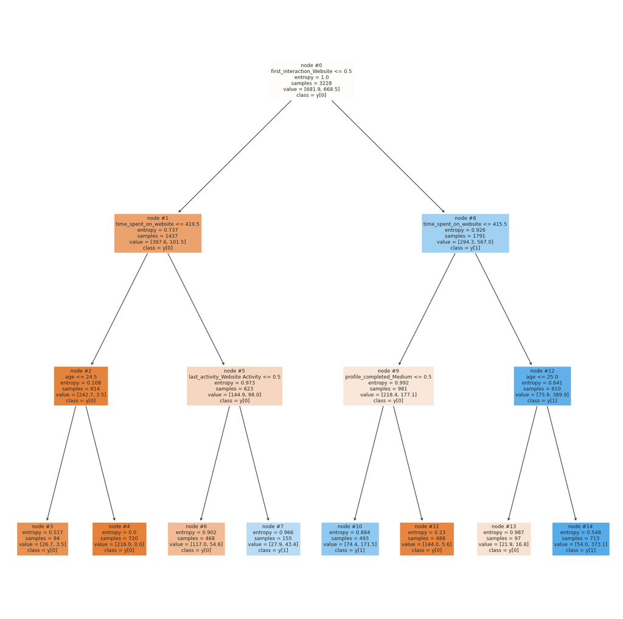

```python
features = list(X.columns)

plt.figure(figsize = (20, 20))

tree.plot_tree(d_tree_tuned, feature_names = features, filled = True, fontsize = 9, node_ids = True, class_names = True)

plt.show()
```

```python
# Importance of features in the tree building

print (pd.DataFrame(d_tree_tuned.feature_importances_, columns = ["Imp"], index = X_train.columns).sort_values(by = 'Imp', ascending = False))
```

```
                                     Imp
time_spent_on_website           0.348142
first_interaction_Website       0.327181
profile_completed_Medium        0.239274
age                             0.063893
last_activity_Website Activity  0.021511
website_visits                  0.000000
page_views_per_visit            0.000000
current_occupation_Student      0.000000
current_occupation_Unemployed   0.000000
profile_completed_Low           0.000000
last_activity_Phone Activity    0.000000
print_media_type1_Yes           0.000000
print_media_type2_Yes           0.000000
digital_media_Yes               0.000000
educational_channels_Yes        0.000000
referral_Yes                    0.000000
```

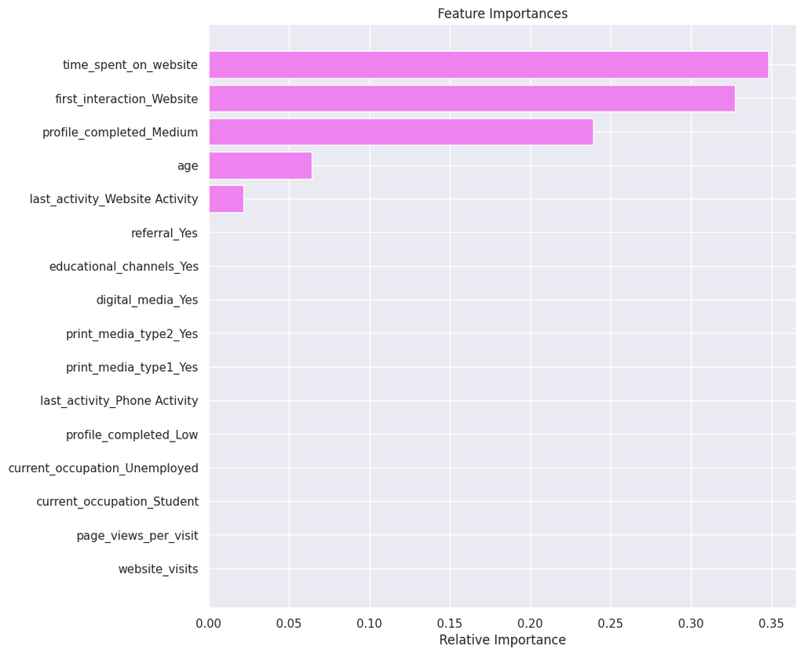

```python
# Plotting the feature importance
importances = d_tree_tuned.feature_importances_

indices = np.argsort(importances)

plt.figure(figsize = (10, 10))

plt.title('Feature Importances')

plt.barh(range(len(indices)), importances[indices], color = 'violet', align = 'center')

plt.yticks(range(len(indices)), [features[i] for i in indices])

plt.xlabel('Relative Importance')

plt.show()
```

The three main features that affect the model and the final outcome of leads being converted to paid customers are time spent on the website, first interaction being on the website, and the profile being fully or partially completed. The age and last activity also are minor factors.

## Building a Random Forest model

```python
# Fitting the random forest tree classifier on the training data
rf_estimator = RandomForestClassifier( random_state = 1)
rf_estimator.fit(X_train, y_train)
```

```
RandomForestClassifier(random_state=1)
```

```
              precision    recall  f1-score   support

           0       1.00      1.00      1.00      2273
           1       1.00      1.00      1.00       955

    accuracy                           1.00      3228
   macro avg       1.00      1.00      1.00      3228
weighted avg       1.00      1.00      1.00      3228
```

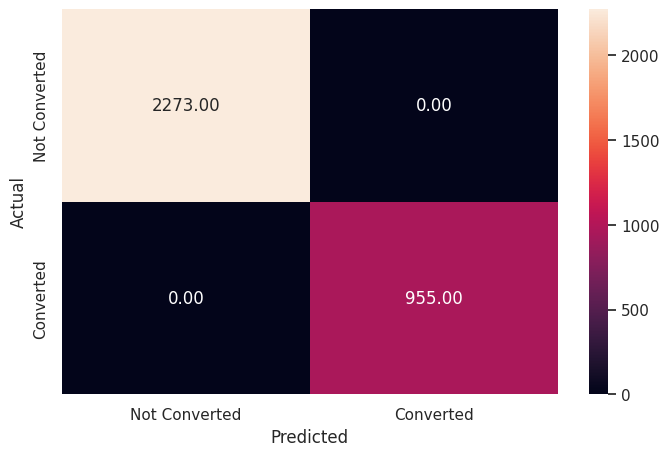

```python
y_pred_train3 = rf_estimator.predict(X_train)
metrics_score(y_train, y_pred_train3)
```

The model fits the training the data perfectly. Lets see how it performs for the test data.

```
              precision    recall  f1-score   support

           0       0.87      0.91      0.89       962
           1       0.78      0.68      0.73       422

    accuracy                           0.84      1384
   macro avg       0.82      0.80      0.81      1384
weighted avg       0.84      0.84      0.84      1384
```

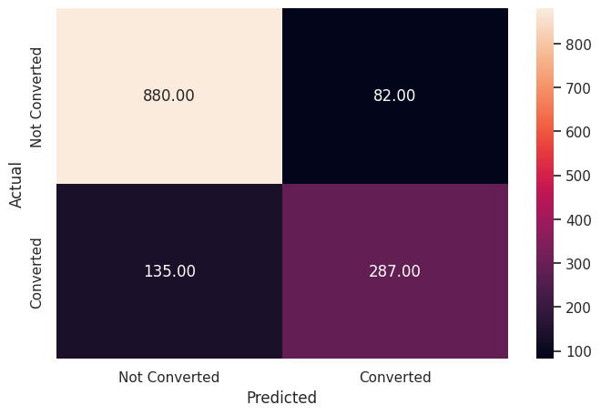

```python
# Checking performance on the testing data
y_pred_test3 = rf_estimator.predict(X_test)
metrics_score(y_test, y_pred_test3)
```

The model does not perform as well for the test data. This means that there is overfitting present on the training data and we need to tune the hyperparameters.

## Do we need to prune the tree?

```python
# Choose the type of classifier
rf_estimator_tuned = RandomForestClassifier(criterion = "entropy", random_state = 7)

# Grid of parameters to choose from
parameters = {"n_estimators": [110, 120],
    "max_depth": [6, 7],
    "min_samples_leaf": [20, 25],
    "max_features": [0.8, 0.9],
    "max_samples": [0.9, 1],
    "class_weight": ["balanced",{0: 0.3, 1: 0.7}]
             }

# Type of scoring used to compare parameter combinations - recall score for class 1
scorer = metrics.make_scorer(recall_score, pos_label = 1)

# Run the grid search on the training data using scorer=scorer and cv=5
grid_obj = GridSearchCV(rf_estimator_tuned, parameters, scoring = scorer, cv = 5)

grid_obj = grid_obj.fit(X_train, y_train)

# Save the best estimator to variable rf_estimator_tuned
rf_estimator_tuned = grid_obj.best_estimator_

# Fit the best algorithm to the data
rf_estimator_tuned.fit(X_train, y_train)
```

```
RandomForestClassifier(class_weight='balanced', criterion='entropy',
                       max_depth=6, max_features=0.8, max_samples=0.9,
                       min_samples_leaf=25, n_estimators=120, random_state=7)
```

```
              precision    recall  f1-score   support

           0       0.94      0.83      0.88      2273
           1       0.68      0.87      0.76       955

    accuracy                           0.84      3228
   macro avg       0.81      0.85      0.82      3228
weighted avg       0.86      0.84      0.84      3228
```

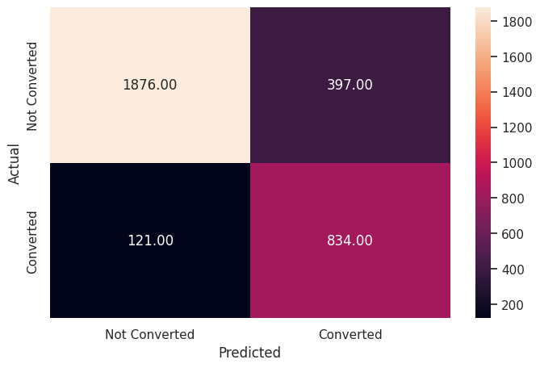

```python
# Checking performance on the training data
y_pred_train4 = rf_estimator_tuned.predict(X_train)
metrics_score(y_train, y_pred_train4)
```

```
              precision    recall  f1-score   support

           0       0.93      0.83      0.87       962
           1       0.68      0.85      0.76       422

    accuracy                           0.83      1384
   macro avg       0.81      0.84      0.82      1384
weighted avg       0.85      0.83      0.84      1384
```

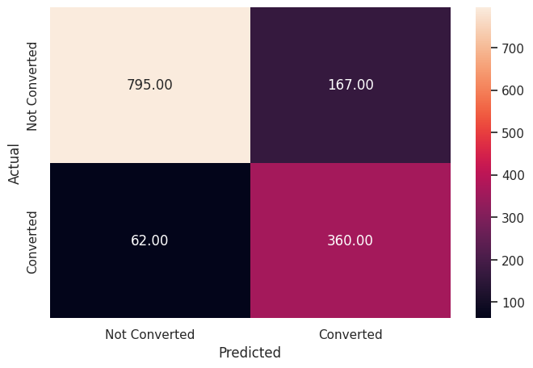

```python
# Checking performance on the testing data
y_pred_test4 = rf_estimator_tuned.predict(X_test)
metrics_score(y_test, y_pred_test4)
```

Now the model gives similar results for both the training and testing data.

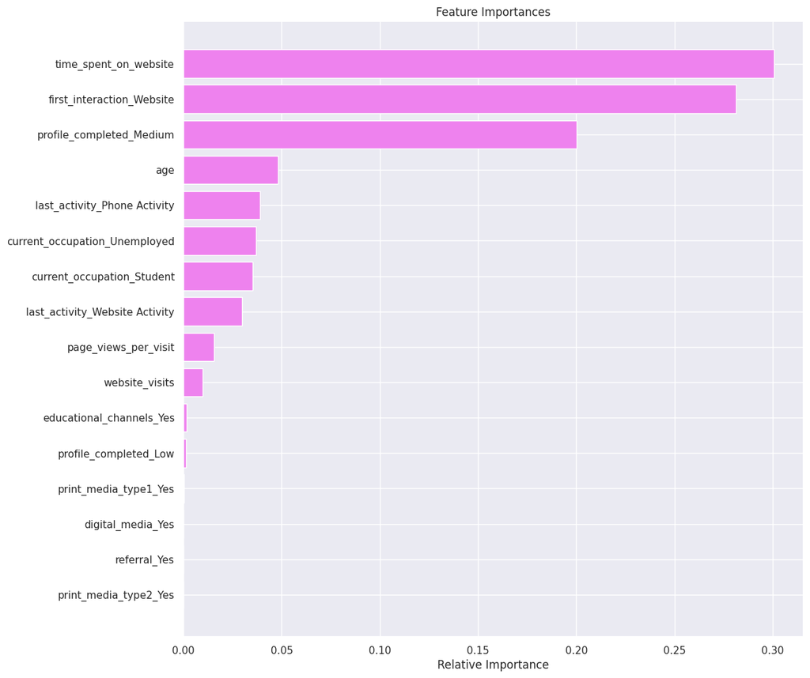

```python
importances = rf_estimator_tuned.feature_importances_

indices = np.argsort(importances)

feature_names = list(X.columns)

plt.figure(figsize = (12, 12))

plt.title('Feature Importances')

plt.barh(range(len(indices)), importances[indices], color = 'violet', align = 'center')

plt.yticks(range(len(indices)), [feature_names[i] for i in indices])

plt.xlabel('Relative Importance')

plt.show()
```

The random forest model gives similar results to the decision tree however the random forest model also gives more importance to some other features such as current occupation, last activity being on the website and page views per visit.

## Actionable Insights and Recommendations

**Based on the data analysis and the modelling, the following can be inferred.**

- ExtraaLearn should focus more on referral and print media type 2 based customers as currently these numbers are not very high. Perhaps some other marketing strategy would help.
- Since more leads using the website become customers, ExtraaLearn should work and improve their business through the mobile app.
- The company should also make the courses lucrative for people who are in their 20s and 30s to get more business.
- The company should also target students to enroll in their courses. This can perhaps be done with student discounts, etc.